# FINAL PROJECT - DRUG CONSUMPTION ANALYSIS

#### Corrélations importantes liées à la consommation de cannabis

Sur l'ensemble des colonnes du dataset (démographie, personnalité et autres drogues) :

On remarque que ce sont d'autres drogues qui sont le plus corrélées à la consommation de cannabis.

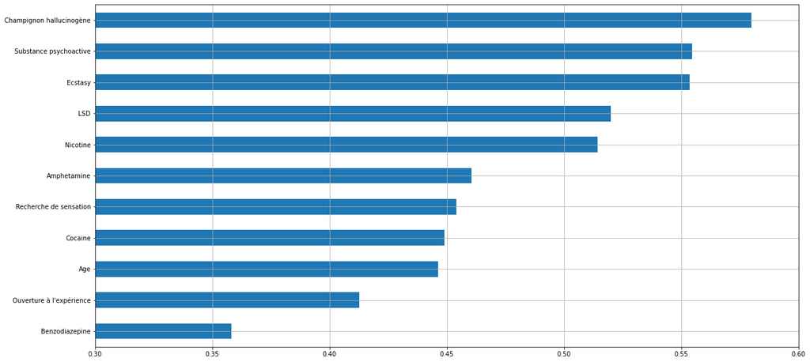

```python
cannabis_corr = data.corr()['Cannabis']
filt = cannabis_corr.apply(lambda x : abs(x) > 0.35 and x != 1)
abs(cannabis_corr[filt]).sort_values().plot.barh(figsize=(20,10), xlim=(0.3,0.6),
                                                    xticks=np.linspace(0.3,0.8,11),
                                                   grid=True)
plt.show()
```

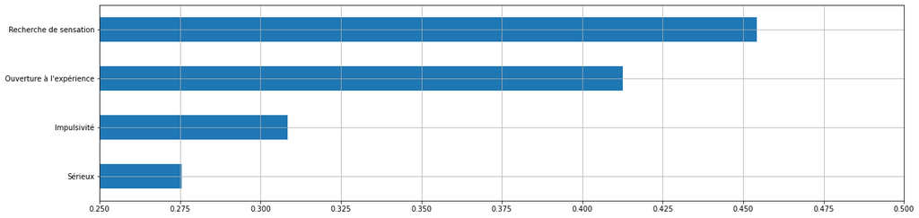

```python
cannabis_corr = data[col_personnalité+ ['Cannabis']].corr()['Cannabis']
filt = cannabis_corr.apply(lambda x : abs(x) > 0.15 and x != 1)
abs(cannabis_corr[filt]).sort_values().plot.barh(figsize=(20,5), xlim=(0.25,0.5),
                                                    xticks=np.linspace(0.25,0.5,11),
                                                   grid=True)
plt.show()
```

Pareil mais en rajoutant les drogues légales

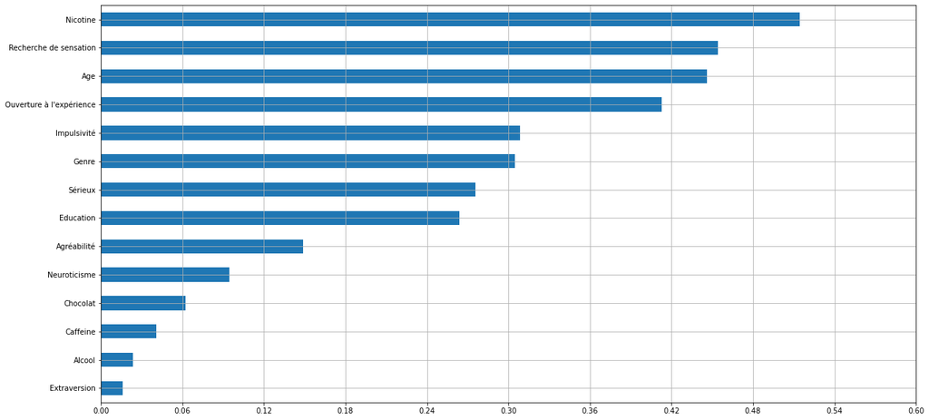

```python
cannabis_corr = data[col_démographie+col_personnalité+col_drogue_légale+ ['Cannabis']].corr()['Cannabis']
filt = cannabis_corr.apply(lambda x : x != 1)
abs(cannabis_corr[filt]).sort_values().plot.barh(figsize=(20,10), xlim=(0,0.6),
                                                    xticks=np.linspace(0,0.6,11),
                                                   grid=True)
plt.show()
```

#### Corrélations importantes liées à la consommation d'alcool

Sur l'ensemble des colonnes du dataset (démographie, personnalité et autres drogues) :

On remarque que ce sont les variables Education, Cafféine et recherche de sensation les plus correlées à la consommation d'alcool.

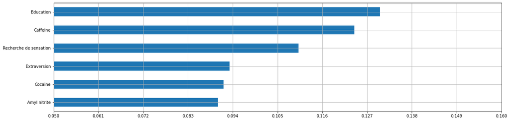

```python
alcool_corr = data.corr()['Alcool']
filt = alcool_corr.apply(lambda x : abs(x) > 0.09 and x != 1)
abs(alcool_corr[filt]).sort_values().plot.barh(figsize=(20,5),  xlim=(0.05,0.16),
                                                    xticks=np.linspace(0.05,0.16,11),
                                                   grid=True)
plt.show()
```

Uniquement sur les colonnes caractéristiques (démographie et personnalité, en excluant les autres drogues) :

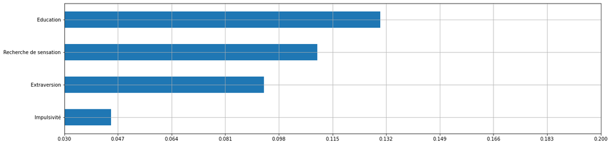

```python
alcool_corr = data[col_démographie+col_personnalité+ ['Alcool']].corr()['Alcool']
filt = alcool_corr.apply(lambda x : abs(x) > 0.035 and x != 1)
abs(alcool_corr[filt]).sort_values().plot.barh(figsize=(20,5), xlim=(0.03,0.2),
                                                    xticks=np.linspace(0.03,0.2,11),
                                                   grid=True)
plt.show()
```

#### Corrélations importantes liées à la recherche de sensation

Ici, on cherche à savoir quelles drogues sont les plus liées aux personnes qui recherchent des sensations.

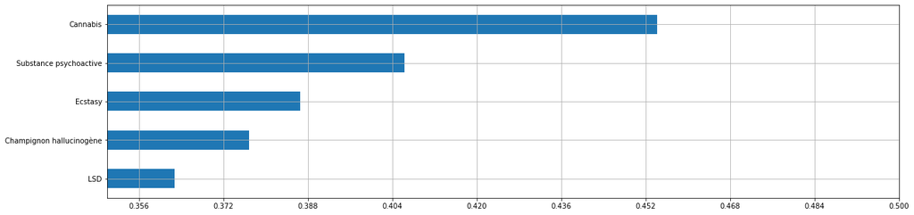

```python
cor = data[col_drogue +['Recherche de sensation']].corr()['Recherche de sensation']
filt = cor.apply(lambda x : abs(x) > 0.35 and x != 1)
abs(cor[filt]).sort_values().plot.barh(figsize=(20,5),  xlim=(0.35,0.5),
                                                    xticks=np.linspace(0.34,0.5,11),
                                                   grid=True)
plt.show()
```

#### Corrélations importantes liées à l'ouverture à l'expérience

Ici, on cherche à savoir quelles drogues sont les plus liées aux personnes qui sont ouvertes à l'expérience.

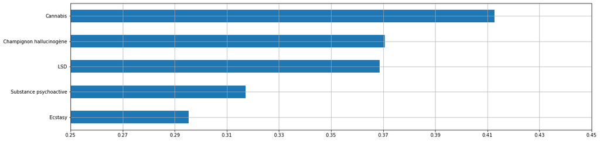

```python
cor = data[col_drogue +['Ouverture à l\'expérience']].corr()['Ouverture à l\'expérience']
filt = cor.apply(lambda x : abs(x) > 0.25 and x != 1)
abs(cor[filt]).sort_values().plot.barh(figsize=(20,5),  xlim=(0.25,0.45),
                                                    xticks=np.linspace(0.25,0.45,11),
                                                   grid=True)
plt.show()
```

# 3_Data Modeling

# Prédictions

#### Choix des drogues à prédire

On doit choisir des drogues à la fois suffisamment équilibrée et dont la corrélation avec les variables explicatives est suffisamment élevée.

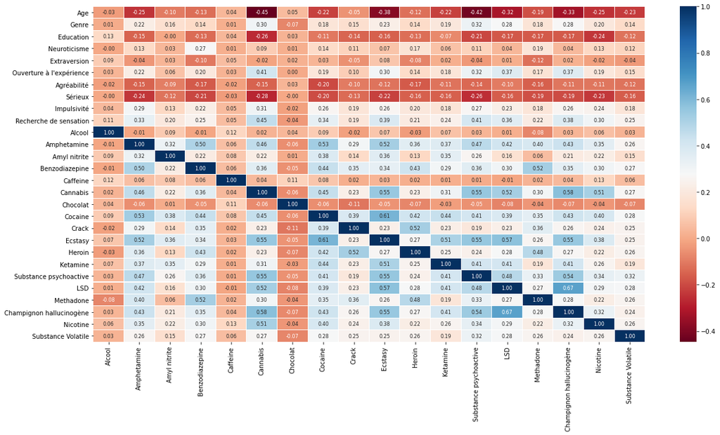

```python
corr = data.corr()[col_drogue]
plt.figure(figsize=(20,10))
sns.heatmap(corr, cmap='RdBu',annot=True, annot_kws={"fontsize":8}, linewidth = 0.1, fmt='.2f')
```

Le cannabis, l'ecstasy, les champignons hallucinogène et le lsd ont des bonnes corrélations.

### Analyse de la consommation d'Ecstasie

#### Création d'une base de donnée améliorée en enlevant les features les moins corrélées à la consommation d'Ecstasie

```python
autres_drogues=col_drogue_illégale.copy()
```

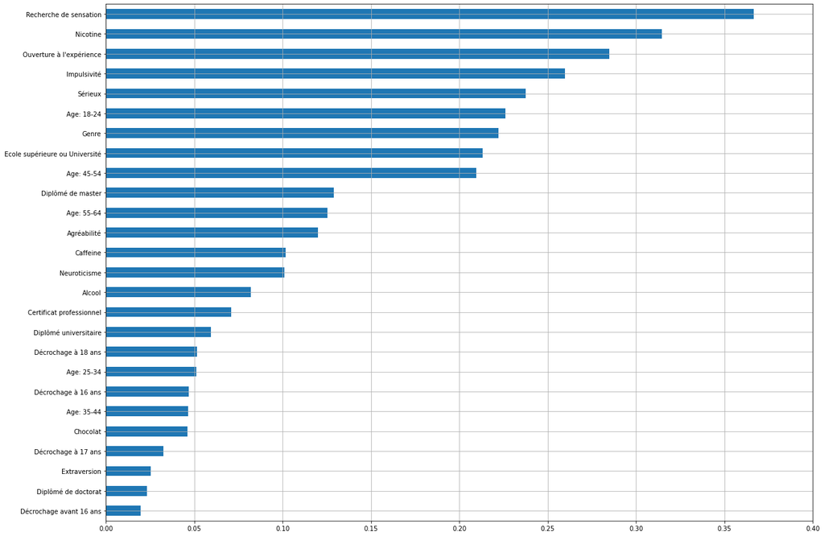

```python
ecstasy_corr = oh_data.drop(autres_drogues,axis=1).corr()['Ecstasy']
filt = ecstasy_corr.apply(lambda x : x != 1)
ecstasy_corr=abs(ecstasy_corr[filt]).sort_values()
ecstasy_corr.plot.barh(figsize=(20,15), xlim=(0,0.4),
                                                    xticks=np.linspace(0,0.5,11),
                                                   grid=True)
plt.show()
```

```python
ecstasy_corr[:12]
```

```
Décrochage avant 16 ans     0.019550
Diplômé de doctorat         0.023329
Extraversion                0.025434
Décrochage à 17 ans         0.032600
Chocolat                    0.046356
Age: 35-44                  0.046665
Décrochage à 16 ans         0.046854
Age: 25-34                  0.051096
Décrochage à 18 ans         0.051672
Diplômé universitaire       0.059522
Certificat professionnel    0.070942
Alcool                      0.081930
Name: Ecstasy, dtype: float64
```

```python
improved_data=oh_data.drop(ecstasy_corr[:12].index,axis=1)
```

```python
improved_data.head()
```

| ID | Genre | Neuroticisme | Ouverture à l'expérience | Agréabilité | Sérieux | Impulsivité | Recherche de sensation | Amphetamine | Amyl nitrite | Benzodiazepine | Caffeine | Cannabis | Cocaine | Crack | Ecstasy | Heroin | Ketamine | Substance psychoactive | LSD | Methadone | Champignon hallucinogène | Nicotine | Substance Volatile | Age: 18-24 | Age: 45-54 | Age: 55-64 | Ecole supérieure ou Université | Diplômé de master |
| --- | --- | --- | --- | --- | --- | --- | --- | --- | --- | --- | --- | --- | --- | --- | --- | --- | --- | --- | --- | --- | --- | --- | --- | --- | --- | --- | --- | --- |
| 1 | 0 | 0.31287 | -0.58331 | -0.91699 | -0.00665 | -0.21712 | -1.18084 | 1 | 0 | 1 | 1 | 0 | 0 | 0 | 0 | 0 | 0 | 0 | 0 | 0 | 0 | 1 | 0 | 0 | 0 | 0 | 0 | 0 |
| 2 | 1 | -0.67825 | 1.43533 | 0.76096 | -0.14277 | -0.71126 | -0.21575 | 1 | 1 | 0 | 1 | 1 | 1 | 0 | 1 | 0 | 1 | 0 | 1 | 1 | 0 | 1 | 0 | 0 | 0 | 0 | 0 | 0 |
| 3 | 1 | -0.46725 | -0.84732 | -1.62090 | -1.01450 | -1.37983 | 0.40148 | 0 | 0 | 0 | 1 | 1 | 0 | 0 | 0 | 0 | 0 | 0 | 0 | 0 | 1 | 0 | 0 | 0 | 0 | 0 | 0 | 0 |
| 4 | 0 | -0.14882 | -0.01928 | 0.59042 | 0.58489 | -1.37983 | -1.18084 | 0 | 0 | 1 | 1 | 1 | 1 | 0 | 0 | 0 | 1 | 0 | 0 | 0 | 0 | 1 | 0 | 1 | 0 | 0 | 0 | 1 |
| 5 | 0 | 0.73545 | -0.45174 | -0.30172 | 1.30612 | -0.21712 | -0.21575 | 1 | 1 | 0 | 1 | 1 | 0 | 0 | 1 | 0 | 0 | 1 | 0 | 0 | 1 | 1 | 0 | 0 | 0 | 0 | 0 | 0 |

### Regression Logistique

```
              precision    recall  f1-score   support

           0       0.73      0.73      0.73       302
           1       0.69      0.70      0.69       262

    accuracy                           0.71       564
   macro avg       0.71      0.71      0.71       564
weighted avg       0.71      0.71      0.71       564
```

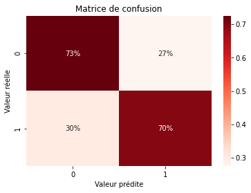

```python
LR=LogisticRegression(penalty='l1', solver='saga', multi_class='multinomial')
LR.fit(X_train, y_train)
LR_pred=LR.predict(X_test)
report_performance(LR)

LR_pred_proba=LR.predict_proba(X_test)[:,1]
fpr_LR, tpr_LR, thresholds_LR = roc_curve(y_test, LR_pred)
roc_auc_LR = auc(fpr_LR, tpr_LR)
```

#### Cross_val_score

```python
metrics_list = ['f1','accuracy','precision','recall','roc_auc']
scores = pd.DataFrame(index=metrics_list, columns=['score'])

#implementation de cross_val_score pour chaque métrique
for metric in metrics_list:
    score= cross_val_score(LR, X_train, y_train, scoring=metric).mean()
    scores.loc[metric] = [score]
scores
```

|  | score |
| --- | --- |
| f1 | 0.705846 |
| accuracy | 0.730328 |
| precision | 0.699954 |
| recall | 0.712605 |
| roc_auc | 0.80702 |

##### Grid search

```
Best params:
 {'C': 1.0, 'penalty': 'l2', 'solver': 'lbfgs'}
Train f1 score: 0.700
Test f1 score: 0.692
              precision    recall  f1-score   support

           0       0.73      0.72      0.73       302
           1       0.69      0.70      0.69       262

    accuracy                           0.71       564
   macro avg       0.71      0.71      0.71       564
weighted avg       0.71      0.71      0.71       564
```

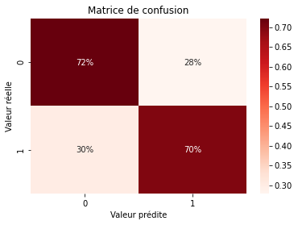

```python
#sources :
#https://medium.com/@data.science.enthusiast/logistic-regression-tune-hyperparameters-python-code-fintech-does-it-bring-any-value-619e172565e6
#https://machinelearningmastery.com/hyperparameters-for-classification-machine-learning-algorithms/

#lbfgs is an overall best performer compared to other methods and is memory efficient. You may encounter convergence issues though.
#saga is also suitable for very large datasets, you can choose this solver for sparse multinomial logistic regression.

# modèle et hyper paramètres
model = LogisticRegression()
solvers = ['lbfgs', 'saga']
penalty = ['none', 'l1', 'l2']
c_values = [100, 10, 1.0, 0.1, 0.01]
# Grid search
grid = dict(solver=solvers,penalty=penalty,C=c_values)
cv = RepeatedStratifiedKFold(n_splits=10, n_repeats=3, random_state=1)
LR_gs = GridSearchCV(estimator=model, param_grid=grid, n_jobs=-1, cv=cv, scoring='f1',error_score=0)
LR_grid_result = LR_gs.fit(X_train, y_train)
# Résultats
LR_grid_score=LR_grid_result.score(X_test, y_test)
print('\nBest params:\n', LR_grid_result.best_params_)
print('Train f1 score: %.3f' % LR_grid_result.best_score_)
print('Test f1 score: %.3f' % LR_grid_score)
report_performance(LR_gs)
```

#### Decision Tree

```
              precision    recall  f1-score   support

           0       0.78      0.63      0.70       302
           1       0.65      0.80      0.72       262

    accuracy                           0.71       564
   macro avg       0.72      0.72      0.71       564
weighted avg       0.72      0.71      0.71       564
```

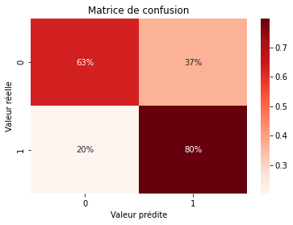

```python
from sklearn.tree import DecisionTreeClassifier
DT=DecisionTreeClassifier(criterion='gini',max_depth=4,random_state=0)
DT.fit(X_train, y_train.ravel())
report_performance(DT)
```

##### Grid Search

```
Best params:
 {'criterion': 'gini', 'max_depth': 10, 'min_samples_leaf': 50}
Train f1 score: 0.681
Test f1 score: 0.691
              precision    recall  f1-score   support

           0       0.74      0.68      0.71       302
           1       0.66      0.73      0.69       262

    accuracy                           0.70       564
   macro avg       0.70      0.70      0.70       564
weighted avg       0.70      0.70      0.70       564
```

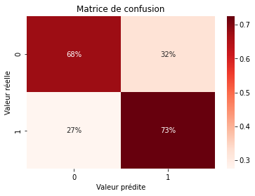

```python
# modèle et hyper paramètres
model=DecisionTreeClassifier()
grid = {
    'max_depth': [2, 3, 5, 10, 20],
    'min_samples_leaf': [5, 10, 20, 50, 100],
    'criterion': ["gini", "entropy"]}
# Grid search
cv = RepeatedStratifiedKFold(n_splits=10, n_repeats=3, random_state=1)
DT_gs = GridSearchCV(estimator=model, param_grid=grid, n_jobs=-1, cv=cv, scoring='f1',error_score=0)
DT_grid_result = DT_gs.fit(X_train, y_train)
# Résultats
DT_grid_score= DT_grid_result.score(X_test, y_test)
print('\nBest params:\n', DT_grid_result.best_params_)
print('Train f1 score: %.3f' % DT_grid_result.best_score_)
print('Test f1 score: %.3f' % DT_grid_score)
report_performance(DT_gs)
```

#### KNN

```python
hide_toggle(for_next=True)
```

Toggle show/hide next cell

```
              precision    recall  f1-score   support

           0       0.72      0.67      0.69       302
           1       0.64      0.70      0.67       262

    accuracy                           0.68       564
   macro avg       0.68      0.68      0.68       564
weighted avg       0.68      0.68      0.68       564
```

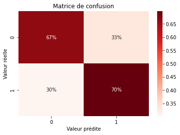

```python
from sklearn.neighbors import KNeighborsClassifier
KNN=KNeighborsClassifier()
KNN.fit(X_train,y_train)
report_performance(KNN)
```

##### Grid Search

```
Best params:
 {'metric': 'manhattan', 'n_neighbors': 19, 'weights': 'uniform'}
Train f1 score: 0.708
Test f1 score: 0.692
              precision    recall  f1-score   support

           0       0.74      0.67      0.70       302
           1       0.66      0.73      0.69       262

    accuracy                           0.70       564
   macro avg       0.70      0.70      0.70       564
weighted avg       0.70      0.70      0.70       564
```

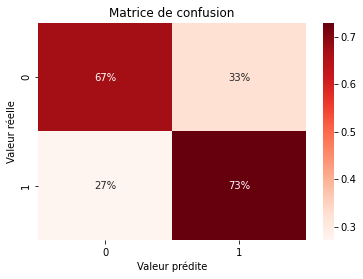

```python
# modèle et hyper paramètres
n_neighbors = range(1, 21, 2)
weights = ['uniform', 'distance']
metric = ['euclidean', 'manhattan', 'minkowski']
# Grid search
grid = dict(n_neighbors=n_neighbors,weights=weights,metric=metric)
cv = RepeatedStratifiedKFold(n_splits=10, n_repeats=3, random_state=1)
KNN_gs = GridSearchCV(estimator=KNN, param_grid=grid, n_jobs=-1, cv=cv, scoring='f1',error_score=0)
KNN_grid_result = KNN_gs.fit(X_train, y_train)
# Résultats
KNN_grid_score=KNN_grid_result.score(X_test, y_test)
print('\nBest params:\n', KNN_grid_result.best_params_)
print('Train f1 score: %.3f' % KNN_grid_result.best_score_)
print('Test f1 score: %.3f' % KNN_grid_score)
report_performance(KNN_gs)
```

#### Support Vector Machine

```
              precision    recall  f1-score   support

           0       0.73      0.69      0.71       302
           1       0.66      0.71      0.69       262

    accuracy                           0.70       564
   macro avg       0.70      0.70      0.70       564
weighted avg       0.70      0.70      0.70       564
```

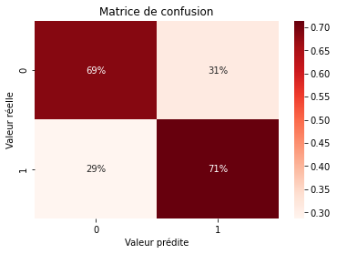

```python
from sklearn.svm import SVC
SVM=SVC()
SVM.fit(X_train,y_train)
report_performance(SVM)
```

##### Grid Search

```
Best params:
 {'C': 0.01, 'gamma': 'scale', 'kernel': 'linear'}
Train f1 score: 0.711
Test f1 score: 0.698
              precision    recall  f1-score   support

           0       0.74      0.72      0.73       302
           1       0.69      0.71      0.70       262

    accuracy                           0.71       564
   macro avg       0.71      0.71      0.71       564
weighted avg       0.72      0.71      0.71       564
```

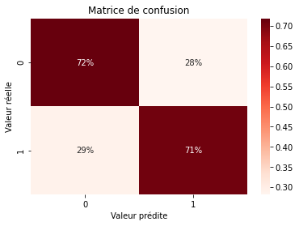

```python
model = SVC(probability=True)
kernel = ['poly', 'rbf', 'sigmoid','linear']
C = [50, 10, 1.0, 0.1, 0.01]
gamma = ['scale']
# define grid search
grid = dict(kernel=kernel,C=C,gamma=gamma)
cv = RepeatedStratifiedKFold(n_splits=10, n_repeats=3, random_state=1)
SVM_gs = GridSearchCV(estimator=model, param_grid=grid, n_jobs=-1, cv=cv, scoring='f1',error_score=0)
SVM_grid_result = SVM_gs.fit(X_train, y_train)
# Résultats
SVM_grid_score=SVM_grid_result.score(X_test, y_test)
print('\nBest params:\n', SVM_grid_result.best_params_)
print('Train f1 score: %.3f' % SVM_grid_result.best_score_)
print('Test f1 score: %.3f' % SVM_grid_score)
report_performance(SVM_gs)
```

#### Random Forest

```
              precision    recall  f1-score   support

           0       0.73      0.72      0.72       302
           1       0.68      0.70      0.69       262

    accuracy                           0.71       564
   macro avg       0.71      0.71      0.71       564
weighted avg       0.71      0.71      0.71       564
```

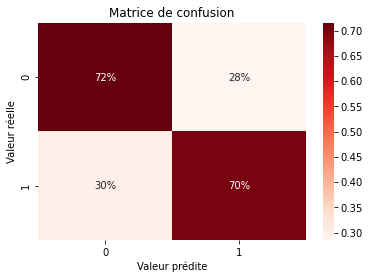

```python
from sklearn.ensemble import RandomForestClassifier
RF = RandomForestClassifier(random_state = 21)
RF.fit(X_train,y_train)
report_performance(RF)
```

#### Grid search

```
Best params:
 {'criterion': 'entropy', 'max_depth': 7, 'max_features': 'auto', 'n_estimators': 500}
Train f1 score: 0.696
Test f1 score: 0.704
              precision    recall  f1-score   support

           0       0.75      0.71      0.73       302
           1       0.68      0.73      0.70       262

    accuracy                           0.72       564
   macro avg       0.72      0.72      0.72       564
weighted avg       0.72      0.72      0.72       564
```

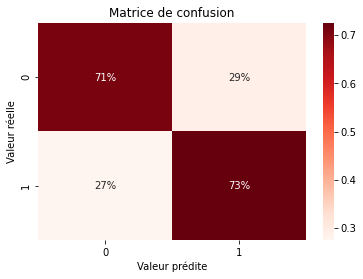

```python
grid = {
    'n_estimators': [200, 500],
    'max_features': ['auto', 'sqrt', 'log2'],
    'max_depth' : [4,5,6,7,8],
    'criterion' :['gini', 'entropy']}
cv = RepeatedStratifiedKFold(n_splits=10, n_repeats=3, random_state=1)
RF_gs = GridSearchCV(estimator=RF, param_grid=grid, n_jobs=-1, cv=cv, scoring='f1',error_score=0)
RF_grid_result = RF_gs.fit(X_train, y_train)
# Résultats
RF_grid_score=RF_grid_result.score(X_test, y_test)
print('\nBest params:\n', RF_grid_result.best_params_)
print('Train f1 score: %.3f' % RF_grid_result.best_score_)
print('Test f1 score: %.3f' % RF_grid_score)
report_performance(RF_gs)
```

#### Comparaison courbes ROC et f1-score

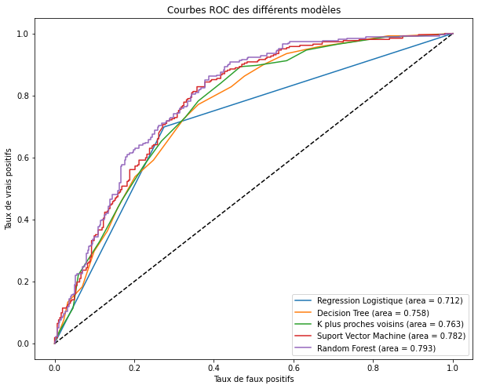

```python
plt.figure(figsize=(10, 8))
plt.plot([0, 1], [0, 1], 'k--')
plt.plot(fpr_LR, tpr_LR, label='Regression Logistique (area = %0.3f)' % roc_auc_LR)
plt.plot(fpr_DT, tpr_DT, label='Decision Tree (area = %0.3f)' % roc_auc_DT)
plt.plot(fpr_KNN, tpr_KNN, label='K plus proches voisins (area = %0.3f)' % roc_auc_KNN)
plt.plot(fpr_SVM, tpr_SVM, label='Suport Vector Machine (area = %0.3f)' % roc_auc_SVM)
plt.plot(fpr_RF, tpr_RF, label='Random Forest (area = %0.3f)' % roc_auc_RF)
plt.xlabel('Taux de faux positifs')
plt.ylabel('Taux de vrais positifs')
plt.title('Courbes ROC des différents modèles')
plt.legend(loc='best')
plt.show()
```

On obtient des scores AUC moins bons que pour le cannabis, mais les donnée sont mieux réparties donc le shéma et plus représentatif.

```python
metriques=['Regression Logistique','Decision Tree','K plus proches voisins','Suport Vector Machine','Random Forest']
f1_scores=[LR_grid_score,DT_grid_score,KNN_grid_score,SVM_grid_score,RF_grid_score]
meilleurs_scores=pd.DataFrame(index=metriques, data=f1_scores, columns=['f1-score'])
meilleurs_scores.sort_values(by='f1-score', ascending=False)
```

|  | f1-score |
| --- | --- |
| Random Forest | 0.703704 |
| Suport Vector Machine | 0.697936 |
| K plus proches voisins | 0.692029 |
| Regression Logistique | 0.691871 |
| Decision Tree | 0.690909 |

### Analyse de la consommation de champignons hallucinogènes

#### Création d'une base de donnée améliorée en enlevant les features les moins corrélées à la consommation de champignons hallucinogènes

```python
oh_data.head()
```

| ID | Genre | Neuroticisme | Extraversion | Ouverture à l'expérience | Agréabilité | Sérieux | Impulsivité | Recherche de sensation | Alcool | Amphetamine | Amyl nitrite | Benzodiazepine | Caffeine | Cannabis | Chocolat | Cocaine | Crack | Ecstasy | Heroin | Ketamine | Substance psychoactive | LSD | Methadone | Champignon hallucinogène | Nicotine | Substance Volatile | Age: 18-24 | Age: 25-34 | Age: 35-44 | … |
| --- | --- | --- | --- | --- | --- | --- | --- | --- | --- | --- | --- | --- | --- | --- | --- | --- | --- | --- | --- | --- | --- | --- | --- | --- | --- | --- | --- | --- | --- | --- |
| 1 | 0 | 0.31287 | -0.57545 | -0.58331 | -0.91699 | -0.00665 | -0.21712 | -1.18084 | 1 | 1 | 0 | 1 | 1 | 0 | 1 | 0 | 0 | 0 | 0 | 0 | 0 | 0 | 0 | 0 | 1 | 0 | 0 | 0 | 1 | … |
| 2 | 1 | -0.67825 | 1.93886 | 1.43533 | 0.76096 | -0.14277 | -0.71126 | -0.21575 | 1 | 1 | 1 | 0 | 1 | 1 | 1 | 1 | 0 | 1 | 0 | 1 | 0 | 1 | 1 | 0 | 1 | 0 | 0 | 1 | 0 | … |
| 3 | 1 | -0.46725 | 0.80523 | -0.84732 | -1.62090 | -1.01450 | -1.37983 | 0.40148 | 1 | 0 | 0 | 0 | 1 | 1 | 1 | 0 | 0 | 0 | 0 | 0 | 0 | 0 | 0 | 1 | 0 | 0 | 0 | 0 | 1 | … |
| 4 | 0 | -0.14882 | -0.80615 | -0.01928 | 0.59042 | 0.58489 | -1.37983 | -1.18084 | 1 | 0 | 0 | 1 | 1 | 1 | 1 | 1 | 0 | 0 | 0 | 1 | 0 | 0 | 0 | 0 | 1 | 0 | 1 | 0 | 0 | … |
| 5 | 0 | 0.73545 | -1.63340 | -0.45174 | -0.30172 | 1.30612 | -0.21712 | -0.21575 | 1 | 1 | 1 | 0 | 1 | 1 | 1 | 0 | 0 | 1 | 0 | 0 | 1 | 0 | 0 | 1 | 1 | 0 | 0 | 0 | 1 | … |

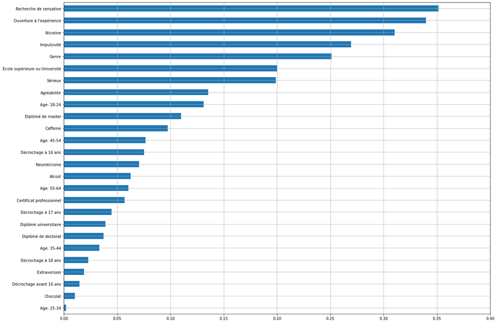

```python
champignon_corr = oh_data.drop(autres_drogues,axis=1).corr()['Champignon hallucinogène']
filt = champignon_corr.apply(lambda x : x != 1)
champignon_corr=abs(champignon_corr[filt]).sort_values()
champignon_corr.plot.barh(figsize=(20,15), xlim=(0,0.4),
                                                    xticks=np.linspace(0,0.5,11),
                                                   grid=True)
plt.show()
```

```python
champignon_corr[:12]
```

```
Age: 25-34                  0.002141
Chocolat                    0.010369
Décrochage avant 16 ans     0.014509
Extraversion                0.018805
Décrochage à 18 ans         0.022879
Age: 35-44                  0.033429
Diplômé de doctorat         0.037328
Diplômé universitaire       0.038983
Décrochage à 17 ans         0.044731
Certificat professionnel    0.056969
Age: 55-64                  0.060679
Alcool                      0.062782
Name: Champignon hallucinogène, dtype: float64
```

```python
improved_data.head()
```

| ID | Genre | Neuroticisme | Ouverture à l'expérience | Agréabilité | Sérieux | Impulsivité | Recherche de sensation | Amphetamine | Amyl nitrite | Benzodiazepine | Caffeine | Cannabis | Cocaine | Crack | Ecstasy | Heroin | Ketamine | Substance psychoactive | LSD | Methadone | Champignon hallucinogène | Nicotine | Substance Volatile | Age: 18-24 | Age: 45-54 | Décrochage à 16 ans | Ecole supérieure ou Université | Diplômé de master |
| --- | --- | --- | --- | --- | --- | --- | --- | --- | --- | --- | --- | --- | --- | --- | --- | --- | --- | --- | --- | --- | --- | --- | --- | --- | --- | --- | --- | --- |
| 1 | 0 | 0.31287 | -0.58331 | -0.91699 | -0.00665 | -0.21712 | -1.18084 | 1 | 0 | 1 | 1 | 0 | 0 | 0 | 0 | 0 | 0 | 0 | 0 | 0 | 0 | 1 | 0 | 0 | 0 | 0 | 0 | 0 |
| 2 | 1 | -0.67825 | 1.43533 | 0.76096 | -0.14277 | -0.71126 | -0.21575 | 1 | 1 | 0 | 1 | 1 | 1 | 0 | 1 | 0 | 1 | 0 | 1 | 1 | 0 | 1 | 0 | 0 | 0 | 0 | 0 | 0 |
| 3 | 1 | -0.46725 | -0.84732 | -1.62090 | -1.01450 | -1.37983 | 0.40148 | 0 | 0 | 0 | 1 | 1 | 0 | 0 | 0 | 0 | 0 | 0 | 0 | 0 | 1 | 0 | 0 | 0 | 0 | 0 | 0 | 0 |
| 4 | 0 | -0.14882 | -0.01928 | 0.59042 | 0.58489 | -1.37983 | -1.18084 | 0 | 0 | 1 | 1 | 1 | 1 | 0 | 0 | 0 | 1 | 0 | 0 | 0 | 0 | 1 | 0 | 1 | 0 | 0 | 0 | 1 |
| 5 | 0 | 0.73545 | -0.45174 | -0.30172 | 1.30612 | -0.21712 | -0.21575 | 1 | 1 | 0 | 1 | 1 | 0 | 0 | 1 | 0 | 0 | 1 | 0 | 0 | 1 | 1 | 0 | 0 | 0 | 0 | 0 | 0 |

```python
X_train, X_test, y_train, y_test=preprocessing_inputs(improved_data, 'Champignon hallucinogène')
```

#### Random Forest

```
              precision    recall  f1-score   support

           0       0.72      0.70      0.71       294
           1       0.68      0.71      0.70       270

    accuracy                           0.70       564
   macro avg       0.70      0.70      0.70       564
weighted avg       0.70      0.70      0.70       564
```

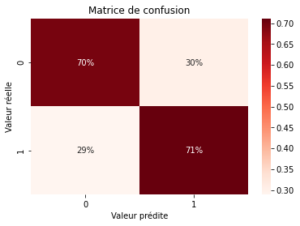

```python
from sklearn.ensemble import RandomForestClassifier
RF = RandomForestClassifier(random_state = 21)
RF.fit(X_train,y_train)
report_performance(RF)
```

#### Grid search

```
Best params:
 {'criterion': 'entropy', 'max_depth': 8, 'max_features': 'auto', 'n_estimators': 500}
Train f1 score: 0.722
Test f1 score: 0.718
              precision    recall  f1-score   support

           0       0.75      0.67      0.71       294
           1       0.68      0.76      0.72       270

    accuracy                           0.71       564
   macro avg       0.72      0.72      0.71       564
weighted avg       0.72      0.71      0.71       564
```

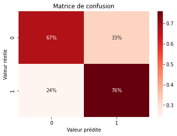

```python
grid = {
    'n_estimators': [200, 500],
    'max_features': ['auto', 'sqrt', 'log2'],
    'max_depth' : [4,5,6,7,8],
    'criterion' :['gini', 'entropy']}
cv = RepeatedStratifiedKFold(n_splits=10, n_repeats=3, random_state=1)
RF_gs = GridSearchCV(estimator=RF, param_grid=grid, n_jobs=-1, cv=cv, scoring='f1',error_score=0)
RF_grid_result = RF_gs.fit(X_train, y_train)
# Résultats
RF_grid_score=RF_grid_result.score(X_test, y_test)
print('\nBest params:\n', RF_grid_result.best_params_)
print('Train f1 score: %.3f' % RF_grid_result.best_score_)
print('Test f1 score: %.3f' % RF_grid_score)
report_performance(RF_gs)
```

```python
RF_pred_proba=RF_gs.predict_proba(X_test)[:,1]
fpr_RF, tpr_RF, thresholds_RF = roc_curve(y_test, RF_pred_proba)
roc_auc_RF = auc(fpr_RF, tpr_RF)
```

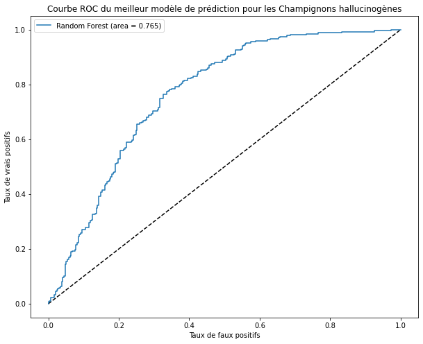

```python
plt.figure(figsize=(10, 8))
plt.plot([0, 1], [0, 1], 'k--')
plt.plot(fpr_RF, tpr_RF, label='Random Forest (area = %0.3f)' % roc_auc_RF)
plt.xlabel('Taux de faux positifs')
plt.ylabel('Taux de vrais positifs')
plt.title('Courbe ROC du meilleur modèle de prédiction pour les Champignons hallucinogènes')
plt.legend(loc='best')
plt.show()
```

### Analyse de la consommation de LSD

```python
autres_drogues=col_drogue_illégale.copy()
```

```python
autres_drogues.remove('LSD')
```

```python
oh_data.head()
```

| ID | Genre | Neuroticisme | Extraversion | Ouverture à l'expérience | Agréabilité | Sérieux | Impulsivité | Recherche de sensation | Alcool | Amphetamine | Amyl nitrite | Benzodiazepine | Caffeine | Cannabis | Chocolat | Cocaine | Crack | Ecstasy | Heroin | Ketamine | Substance psychoactive | LSD | Methadone | Champignon hallucinogène | Nicotine | Substance Volatile | Age: 18-24 | Age: 25-34 | Age: 35-44 | … |
| --- | --- | --- | --- | --- | --- | --- | --- | --- | --- | --- | --- | --- | --- | --- | --- | --- | --- | --- | --- | --- | --- | --- | --- | --- | --- | --- | --- | --- | --- | --- |
| 1 | 0 | 0.31287 | -0.57545 | -0.58331 | -0.91699 | -0.00665 | -0.21712 | -1.18084 | 1 | 1 | 0 | 1 | 1 | 0 | 1 | 0 | 0 | 0 | 0 | 0 | 0 | 0 | 0 | 0 | 1 | 0 | 0 | 0 | 1 | … |
| 2 | 1 | -0.67825 | 1.93886 | 1.43533 | 0.76096 | -0.14277 | -0.71126 | -0.21575 | 1 | 1 | 1 | 0 | 1 | 1 | 1 | 1 | 0 | 1 | 0 | 1 | 0 | 1 | 1 | 0 | 1 | 0 | 0 | 1 | 0 | … |
| 3 | 1 | -0.46725 | 0.80523 | -0.84732 | -1.62090 | -1.01450 | -1.37983 | 0.40148 | 1 | 0 | 0 | 0 | 1 | 1 | 1 | 0 | 0 | 0 | 0 | 0 | 0 | 0 | 0 | 1 | 0 | 0 | 0 | 0 | 1 | … |
| 4 | 0 | -0.14882 | -0.80615 | -0.01928 | 0.59042 | 0.58489 | -1.37983 | -1.18084 | 1 | 0 | 0 | 1 | 1 | 1 | 1 | 1 | 0 | 0 | 0 | 1 | 0 | 0 | 0 | 0 | 1 | 0 | 1 | 0 | 0 | … |
| 5 | 0 | 0.73545 | -1.63340 | -0.45174 | -0.30172 | 1.30612 | -0.21712 | -0.21575 | 1 | 1 | 1 | 0 | 1 | 1 | 1 | 0 | 0 | 1 | 0 | 0 | 1 | 0 | 0 | 1 | 1 | 0 | 0 | 0 | 1 | … |

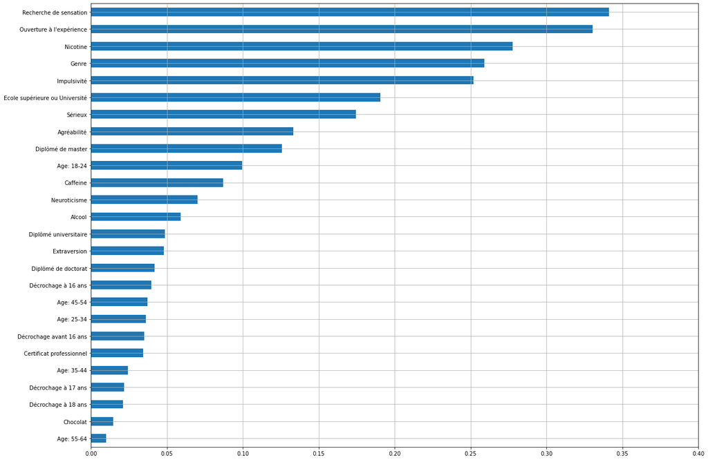

```python
lsd_corr = oh_data.drop(autres_drogues,axis=1).corr()['LSD']
filt = lsd_corr.apply(lambda x : x != 1)
lsd_corr=abs(lsd_corr[filt]).sort_values()
lsd_corr.plot.barh(figsize=(20,15), xlim=(0,0.4),
                                                    xticks=np.linspace(0,0.5,11),
                                                   grid=True)
plt.show()
```

```python
lsd_corr[:12]
```

```
Age: 55-64                  0.010086
Chocolat                    0.014755
Décrochage à 18 ans         0.021099
Décrochage à 17 ans         0.021952
Age: 35-44                  0.024229
Certificat professionnel    0.034426
Décrochage avant 16 ans     0.035032
Age: 25-34                  0.036076
Age: 45-54                  0.037181
Décrochage à 16 ans         0.039597
Diplômé de doctorat         0.042083
Extraversion                0.048169
Name: LSD, dtype: float64
```

```python
improved_data=oh_data.drop(lsd_corr[:12].index,axis=1)
```

```python
improved_data.head()
```

| ID | Genre | Neuroticisme | Ouverture à l'expérience | Agréabilité | Sérieux | Impulsivité | Recherche de sensation | Alcool | Amphetamine | Amyl nitrite | Benzodiazepine | Caffeine | Cannabis | Cocaine | Crack | Ecstasy | Heroin | Ketamine | Substance psychoactive | LSD | Methadone | Champignon hallucinogène | Nicotine | Substance Volatile | Age: 18-24 | Ecole supérieure ou Université | Diplômé universitaire | Diplômé de master |
| --- | --- | --- | --- | --- | --- | --- | --- | --- | --- | --- | --- | --- | --- | --- | --- | --- | --- | --- | --- | --- | --- | --- | --- | --- | --- | --- | --- | --- |
| 1 | 0 | 0.31287 | -0.58331 | -0.91699 | -0.00665 | -0.21712 | -1.18084 | 1 | 1 | 0 | 1 | 1 | 0 | 0 | 0 | 0 | 0 | 0 | 0 | 0 | 0 | 0 | 1 | 0 | 0 | 0 | 0 | 0 |
| 2 | 1 | -0.67825 | 1.43533 | 0.76096 | -0.14277 | -0.71126 | -0.21575 | 1 | 1 | 1 | 0 | 1 | 1 | 1 | 0 | 1 | 0 | 1 | 0 | 1 | 1 | 0 | 1 | 0 | 0 | 0 | 0 | 0 |
| 3 | 1 | -0.46725 | -0.84732 | -1.62090 | -1.01450 | -1.37983 | 0.40148 | 1 | 0 | 0 | 0 | 1 | 1 | 0 | 0 | 0 | 0 | 0 | 0 | 0 | 0 | 1 | 0 | 0 | 0 | 0 | 0 | 0 |
| 4 | 0 | -0.14882 | -0.01928 | 0.59042 | 0.58489 | -1.37983 | -1.18084 | 1 | 0 | 0 | 1 | 1 | 1 | 1 | 0 | 0 | 0 | 1 | 0 | 0 | 0 | 0 | 1 | 0 | 1 | 0 | 0 | 1 |
| 5 | 0 | 0.73545 | -0.45174 | -0.30172 | 1.30612 | -0.21712 | -0.21575 | 1 | 1 | 1 | 0 | 1 | 1 | 0 | 0 | 1 | 0 | 0 | 1 | 0 | 0 | 1 | 1 | 0 | 0 | 0 | 0 | 0 |

```python
X_train, X_test, y_train, y_test=preprocessing_inputs(improved_data, 'LSD')
```

#### Random Forest

```
              precision    recall  f1-score   support

           0       0.72      0.77      0.74       310
           1       0.69      0.63      0.66       254

    accuracy                           0.71       564
   macro avg       0.70      0.70      0.70       564
weighted avg       0.70      0.71      0.70       564
```

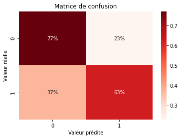

```python
from sklearn.ensemble import RandomForestClassifier
RF = RandomForestClassifier(random_state = 21)
RF.fit(X_train,y_train)
report_performance(RF)
```

#### Grid search

```
Best params:
 {'criterion': 'entropy', 'max_depth': 6, 'max_features': 'auto', 'n_estimators': 500}
Train f1 score: 0.640
Test f1 score: 0.657
              precision    recall  f1-score   support

           0       0.72      0.75      0.73       310
           1       0.68      0.64      0.66       254

    accuracy                           0.70       564
   macro avg       0.70      0.69      0.70       564
weighted avg       0.70      0.70      0.70       564
```

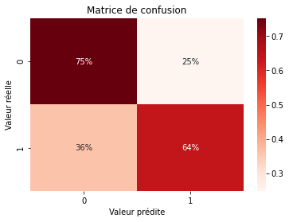

```python
grid = {
    'n_estimators': [200, 500],
    'max_features': ['auto', 'sqrt', 'log2'],
    'max_depth' : [4,5,6,7,8],
    'criterion' :['gini', 'entropy']}
cv = RepeatedStratifiedKFold(n_splits=10, n_repeats=3, random_state=1)
RF_gs = GridSearchCV(estimator=RF, param_grid=grid, n_jobs=-1, cv=cv, scoring='f1',error_score=0)
RF_grid_result = RF_gs.fit(X_train, y_train)
# Résultats
RF_grid_score=RF_grid_result.score(X_test, y_test)
print('\nBest params:\n', RF_grid_result.best_params_)
print('Train f1 score: %.3f' % RF_grid_result.best_score_)
print('Test f1 score: %.3f' % RF_grid_score)
report_performance(RF_gs)
```

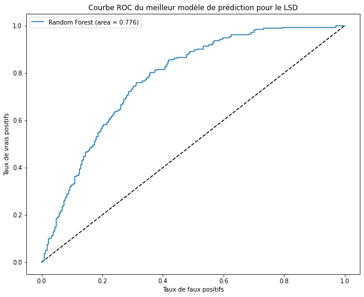

```python
plt.figure(figsize=(10, 8))
plt.plot([0, 1], [0, 1], 'k--')
plt.plot(fpr_RF, tpr_RF, label='Random Forest (area = %0.3f)' % roc_auc_RF)
plt.xlabel('Taux de faux positifs')
plt.ylabel('Taux de vrais positifs')
plt.title('Courbe ROC du meilleur modèle de prédiction pour le LSD')
plt.legend(loc='best')
plt.show()
```

### Analyse de la consommation de Cannabis

```python
oh_data.head()
```

| ID | Genre | Neuroticisme | Extraversion | Ouverture à l'expérience | Agréabilité | Sérieux | Impulsivité | Recherche de sensation | Alcool | Amphetamine | Amyl nitrite | Benzodiazepine | Caffeine | Cannabis | Chocolat | Cocaine | Crack | Ecstasy | Heroin | Ketamine | Substance psychoactive | LSD | Methadone | Champignon hallucinogène | Nicotine | Substance Volatile | Age: 18-24 | Age: 25-34 | Age: 35-44 | … |
| --- | --- | --- | --- | --- | --- | --- | --- | --- | --- | --- | --- | --- | --- | --- | --- | --- | --- | --- | --- | --- | --- | --- | --- | --- | --- | --- | --- | --- | --- | --- |
| 1 | 0 | 0.31287 | -0.57545 | -0.58331 | -0.91699 | -0.00665 | -0.21712 | -1.18084 | 1 | 1 | 0 | 1 | 1 | 0 | 1 | 0 | 0 | 0 | 0 | 0 | 0 | 0 | 0 | 0 | 1 | 0 | 0 | 0 | 1 | … |
| 2 | 1 | -0.67825 | 1.93886 | 1.43533 | 0.76096 | -0.14277 | -0.71126 | -0.21575 | 1 | 1 | 1 | 0 | 1 | 1 | 1 | 1 | 0 | 1 | 0 | 1 | 0 | 1 | 1 | 0 | 1 | 0 | 0 | 1 | 0 | … |
| 3 | 1 | -0.46725 | 0.80523 | -0.84732 | -1.62090 | -1.01450 | -1.37983 | 0.40148 | 1 | 0 | 0 | 0 | 1 | 1 | 1 | 0 | 0 | 0 | 0 | 0 | 0 | 0 | 0 | 1 | 0 | 0 | 0 | 0 | 1 | … |
| 4 | 0 | -0.14882 | -0.80615 | -0.01928 | 0.59042 | 0.58489 | -1.37983 | -1.18084 | 1 | 0 | 0 | 1 | 1 | 1 | 1 | 1 | 0 | 0 | 0 | 1 | 0 | 0 | 0 | 0 | 1 | 0 | 1 | 0 | 0 | … |
| 5 | 0 | 0.73545 | -1.63340 | -0.45174 | -0.30172 | 1.30612 | -0.21712 | -0.21575 | 1 | 1 | 1 | 0 | 1 | 1 | 1 | 0 | 0 | 1 | 0 | 0 | 1 | 0 | 0 | 1 | 1 | 0 | 0 | 0 | 1 | … |

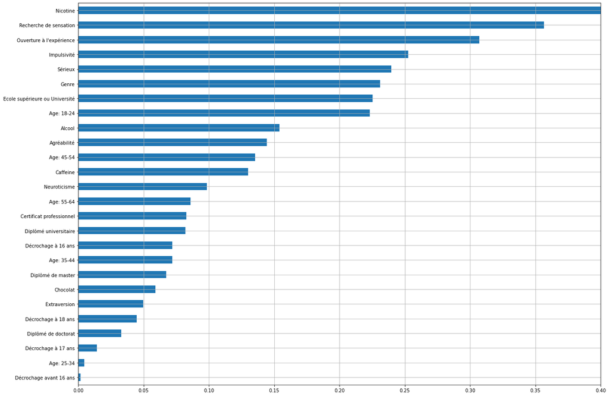

```python
cannabis_corr = oh_data.drop(autres_drogues,axis=1).corr()['Cannabis']
filt = cannabis_corr.apply(lambda x : x != 1)
cannabis_corr=abs(cannabis_corr[filt]).sort_values()
cannabis_corr.plot.barh(figsize=(20,15), xlim=(0,0.4),
                                                    xticks=np.linspace(0,0.5,11),
                                                   grid=True)
plt.show()
```

```python
cannabis_corr[:12]
```

```
Décrochage avant 16 ans     0.001707
Age: 25-34                  0.004762
Décrochage à 17 ans         0.014399
Diplômé de doctorat         0.032780
Décrochage à 18 ans         0.044781
Extraversion                0.049673
Chocolat                    0.059199
Diplômé de master           0.067320
Age: 35-44                  0.071881
Décrochage à 16 ans         0.071900
Diplômé universitaire       0.082135
Certificat professionnel    0.082789
Name: Cannabis, dtype: float64
```

```python
improved_data.head()
```

| ID | Genre | Neuroticisme | Ouverture à l'expérience | Agréabilité | Sérieux | Impulsivité | Recherche de sensation | Alcool | Amphetamine | Amyl nitrite | Benzodiazepine | Caffeine | Cannabis | Cocaine | Crack | Ecstasy | Heroin | Ketamine | Substance psychoactive | LSD | Methadone | Champignon hallucinogène | Nicotine | Substance Volatile | Age: 18-24 | Age: 45-54 | Age: 55-64 | Ecole supérieure ou Université |
| --- | --- | --- | --- | --- | --- | --- | --- | --- | --- | --- | --- | --- | --- | --- | --- | --- | --- | --- | --- | --- | --- | --- | --- | --- | --- | --- | --- | --- |
| 1 | 0 | 0.31287 | -0.58331 | -0.91699 | -0.00665 | -0.21712 | -1.18084 | 1 | 1 | 0 | 1 | 1 | 0 | 0 | 0 | 0 | 0 | 0 | 0 | 0 | 0 | 0 | 1 | 0 | 0 | 0 | 0 | 0 |
| 2 | 1 | -0.67825 | 1.43533 | 0.76096 | -0.14277 | -0.71126 | -0.21575 | 1 | 1 | 1 | 0 | 1 | 1 | 1 | 0 | 1 | 0 | 1 | 0 | 1 | 1 | 0 | 1 | 0 | 0 | 0 | 0 | 0 |
| 3 | 1 | -0.46725 | -0.84732 | -1.62090 | -1.01450 | -1.37983 | 0.40148 | 1 | 0 | 0 | 0 | 1 | 1 | 0 | 0 | 0 | 0 | 0 | 0 | 0 | 0 | 1 | 0 | 0 | 0 | 0 | 0 | 0 |
| 4 | 0 | -0.14882 | -0.01928 | 0.59042 | 0.58489 | -1.37983 | -1.18084 | 1 | 0 | 0 | 1 | 1 | 1 | 1 | 0 | 0 | 0 | 1 | 0 | 0 | 0 | 0 | 1 | 0 | 1 | 0 | 0 | 0 |
| 5 | 0 | 0.73545 | -0.45174 | -0.30172 | 1.30612 | -0.21712 | -0.21575 | 1 | 1 | 1 | 0 | 1 | 1 | 0 | 0 | 1 | 0 | 0 | 1 | 0 | 0 | 1 | 1 | 0 | 0 | 0 | 0 | 0 |

```python
X_train, X_test, y_train, y_test=preprocessing_inputs(improved_data, 'Cannabis')
```

#### Random Forest

```
              precision    recall  f1-score   support

           0       0.73      0.54      0.62       125
           1       0.88      0.94      0.91       439

    accuracy                           0.85       564
   macro avg       0.80      0.74      0.76       564
weighted avg       0.84      0.85      0.84       564
```

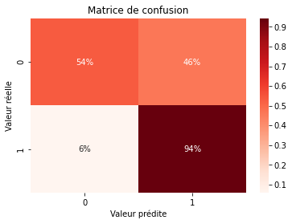

```python
from sklearn.ensemble import RandomForestClassifier
RF = RandomForestClassifier(random_state = 21)
RF.fit(X_train,y_train)
report_performance(RF)
```

#### Grid search

```
Best params:
 {'criterion': 'entropy', 'max_depth': 5, 'max_features': 'auto', 'n_estimators': 500}
Train f1 score: 0.911
Test f1 score: 0.914
              precision    recall  f1-score   support

           0       0.80      0.48      0.60       125
           1       0.87      0.97      0.91       439

    accuracy                           0.86       564
   macro avg       0.83      0.72      0.76       564
weighted avg       0.85      0.86      0.84       564
```

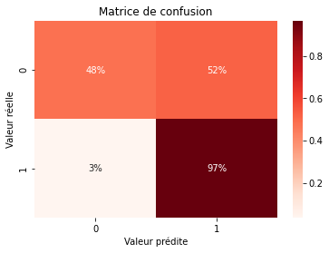

```python
grid = {
    'n_estimators': [200, 500],
    'max_features': ['auto', 'sqrt', 'log2'],
    'max_depth' : [4,5,6,7,8],
    'criterion' :['gini', 'entropy']}
cv = RepeatedStratifiedKFold(n_splits=10, n_repeats=3, random_state=1)
RF_gs = GridSearchCV(estimator=RF, param_grid=grid, n_jobs=-1, cv=cv, scoring='f1',error_score=0)
RF_grid_result = RF_gs.fit(X_train, y_train)
# Résultats
RF_grid_score=RF_grid_result.score(X_test, y_test)
print('\nBest params:\n', RF_grid_result.best_params_)
print('Train f1 score: %.3f' % RF_grid_result.best_score_)
print('Test f1 score: %.3f' % RF_grid_score)
report_performance(RF_gs)
```

```python
RF_pred_proba=RF_gs.predict_proba(X_test)[:,1]
fpr_RF, tpr_RF, thresholds_RF = roc_curve(y_test, RF_pred_proba)
roc_auc_RF = auc(fpr_RF, tpr_RF)
```

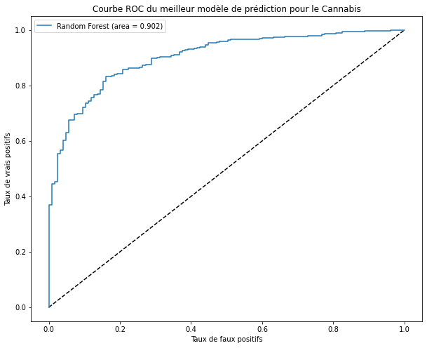

```python
plt.figure(figsize=(10, 8))
plt.plot([0, 1], [0, 1], 'k--')
plt.plot(fpr_RF, tpr_RF, label='Random Forest (area = %0.3f)' % roc_auc_RF)
plt.xlabel('Taux de faux positifs')
plt.ylabel('Taux de vrais positifs')
plt.title('Courbe ROC du meilleur modèle de prédiction pour le Cannabis')
plt.legend(loc='best')
plt.show()
```